# PSYC2020L Assignment 10

[name]

2025-10-24

## Goals for Review:

- Communication

## Setting Up

### 1) Rename this assignment as “Lab 10 Assignment [Last, First].Rmd”

### 2) Check and set (if needed) your working directory. If you’d like to load packages with `library()`, please do so in this block. Please load the `tidyverse`!.

```r
here::here()
```

```
## [1] "C:/Users/jessi/OneDrive - Georgia Institute of Technology/Courses/GTA/PSYC2020L"
```

```r
library(tidyverse)
```

## Communication

In this assignment, we will be working with the `msleep` dataset that comes with the `tidyverse` library. This data set has information of the sleep characteristics for different mammals! Check out the data with `?msleep` to read a little bit about the variables (feel free to comment out or remove afterwards.

### 3) Then, use three functions to get a sense of the data.

```r
head(msleep)
```

```
## # A tibble: 6 × 11
##   name    genus vore  order conservation sleep_total sleep_rem sleep_cycle awake
##   <chr>   <chr> <chr> <chr> <chr>              <dbl>     <dbl>       <dbl> <dbl>
## 1 Cheetah Acin… carni Carn… lc                  12.1      NA        NA      11.9
## 2 Owl mo… Aotus omni  Prim… <NA>                17         1.8      NA       7
## 3 Mounta… Aplo… herbi Rode… nt                  14.4       2.4      NA       9.6
## 4 Greate… Blar… omni  Sori… lc                  14.9       2.3       0.133   9.1
## 5 Cow     Bos   herbi Arti… domesticated         4         0.7       0.667  20
## 6 Three-… Brad… herbi Pilo… <NA>                14.4       2.2       0.767   9.6
## # ℹ 2 more variables: brainwt <dbl>, bodywt <dbl>
```

```r
str(msleep)
```

```
## tibble [83 × 11] (S3: tbl_df/tbl/data.frame)
##  $ name        : chr [1:83] "Cheetah" "Owl monkey" "Mountain beaver" "Greater short-tailed shrew" ...
##  $ genus       : chr [1:83] "Acinonyx" "Aotus" "Aplodontia" "Blarina" ...
##  $ vore        : chr [1:83] "carni" "omni" "herbi" "omni" ...
##  $ order       : chr [1:83] "Carnivora" "Primates" "Rodentia" "Soricomorpha" ...
##  $ conservation: chr [1:83] "lc" NA "nt" "lc" ...
##  $ sleep_total : num [1:83] 12.1 17 14.4 14.9 4 14.4 8.7 7 10.1 3 ...
##  $ sleep_rem   : num [1:83] NA 1.8 2.4 2.3 0.7 2.2 1.4 NA 2.9 NA ...
##  $ sleep_cycle : num [1:83] NA NA NA 0.133 0.667 ...
##  $ awake       : num [1:83] 11.9 7 9.6 9.1 20 9.6 15.3 17 13.9 21 ...
##  $ brainwt     : num [1:83] NA 0.0155 NA 0.00029 0.423 NA NA NA 0.07 0.0982 ...
##  $ bodywt      : num [1:83] 50 0.48 1.35 0.019 600 ...
```

```r
summary(msleep)
```

```
##      name              genus               vore              order
##  Length:83          Length:83          Length:83          Length:83
##  Class :character   Class :character   Class :character   Class :character
##  Mode  :character   Mode  :character   Mode  :character   Mode  :character
##
##
##
##
##  conservation        sleep_total      sleep_rem      sleep_cycle
##  Length:83          Min.   : 1.90   Min.   :0.100   Min.   :0.1167
##  Class :character   1st Qu.: 7.85   1st Qu.:0.900   1st Qu.:0.1833
##  Mode  :character   Median :10.10   Median :1.500   Median :0.3333
##                     Mean   :10.43   Mean   :1.875   Mean   :0.4396
##                     3rd Qu.:13.75   3rd Qu.:2.400   3rd Qu.:0.5792
##                     Max.   :19.90   Max.   :6.600   Max.   :1.5000
##                                     NA's   :22      NA's   :51
##      awake          brainwt            bodywt
##  Min.   : 4.10   Min.   :0.00014   Min.   :   0.005
##  1st Qu.:10.25   1st Qu.:0.00290   1st Qu.:   0.174
##  Median :13.90   Median :0.01240   Median :   1.670
##  Mean   :13.57   Mean   :0.28158   Mean   : 166.136
##  3rd Qu.:16.15   3rd Qu.:0.12550   3rd Qu.:  41.750
##  Max.   :22.10   Max.   :5.71200   Max.   :6654.000
##                  NA's   :27
```

### 4a) Plot the distributions of the variables `sleep_total` and `bodywt` in two separate plots. Feel free to use whatever type of distributional geom you prefer.

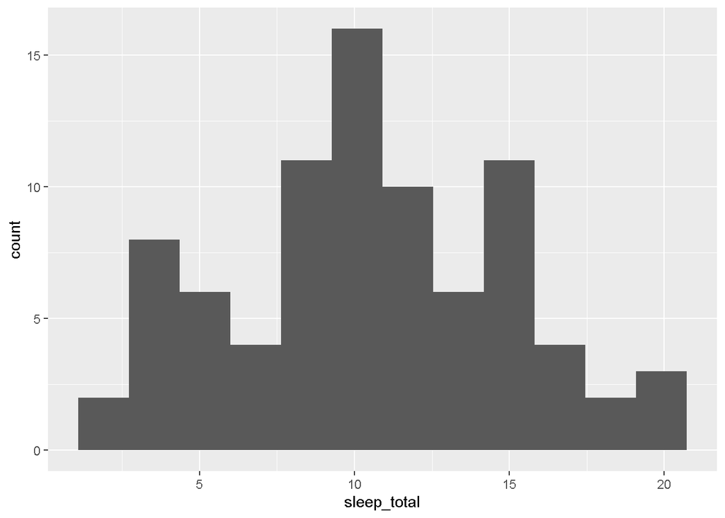

```r
ggplot(msleep, aes(x = sleep_total)) +
  geom_histogram(bins = 12)
```

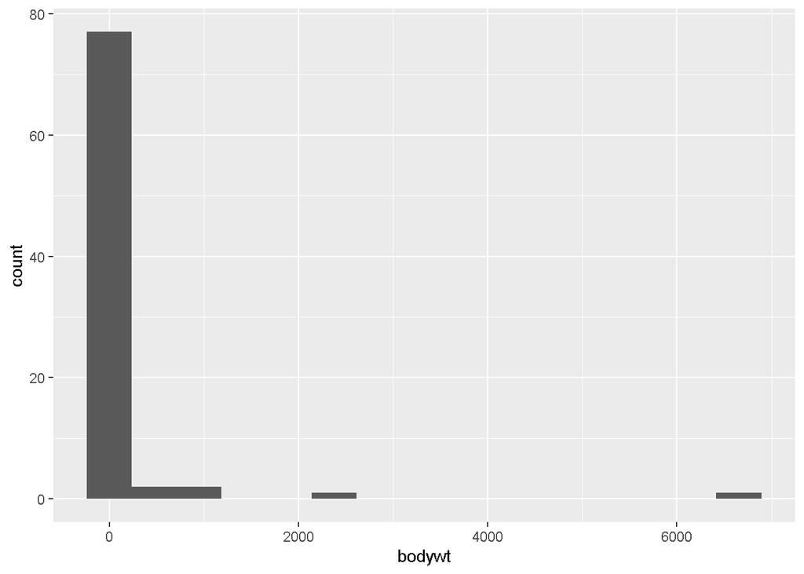

```r
ggplot(msleep, aes(x = bodywt)) +
  geom_histogram(bins = 15)
```

### 4b) Describe what you see in the plots above.

The `sleep_total` variable is normal-ish, with pretty thick tails. It appears pretty symmetrical. The `body_wt` variable has some very large outliers!

### 5a) Make a scatterplot with body weight on the x-axis and total sleep on the y-axis.

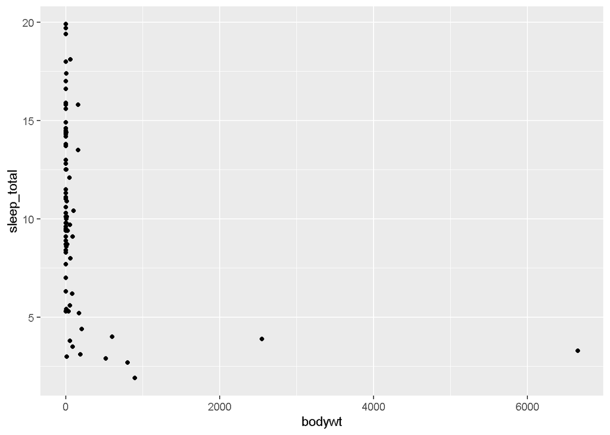

```r
msleep |>
  ggplot(aes(x = bodywt, y = sleep_total)) +
  geom_point()
```

### 5b) Label two points you consider interesting / outliers with the type of animal they are (Hint: first, `filter()` the data to see what the animal names are for the points you select. Then, `annotate()` the data with a `text` geom at `x` and `y` values close to the selected points. You can absolutely use another solution to label if you’d like; this is just one way).

```r
msleep |>
  filter(bodywt > 2000)
```

```
## # A tibble: 2 × 11
##   name    genus vore  order conservation sleep_total sleep_rem sleep_cycle awake
##   <chr>   <chr> <chr> <chr> <chr>              <dbl>     <dbl>       <dbl> <dbl>
## 1 Asian … Elep… herbi Prob… en                   3.9        NA          NA  20.1
## 2 Africa… Loxo… herbi Prob… vu                   3.3        NA          NA  20.7
## # ℹ 2 more variables: brainwt <dbl>, bodywt <dbl>
```

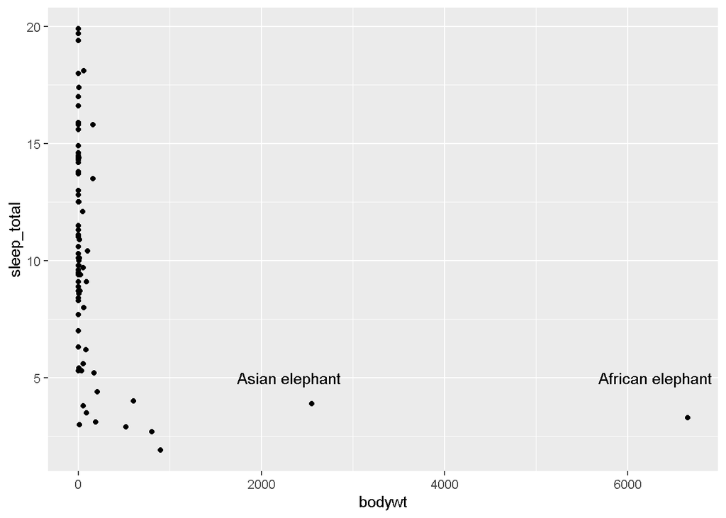

```r
msleep |>
  ggplot(aes(x = bodywt, y = sleep_total)) +
  geom_point() +
  annotate("text", x = 2300, y = 5, label = "Asian elephant") +
  annotate("text", x = 6300, y = 5, label = "African elephant")
```

### 5c) Modify the x-axis label and y-axis label to be more readable and descriptive. Make sure to add units!

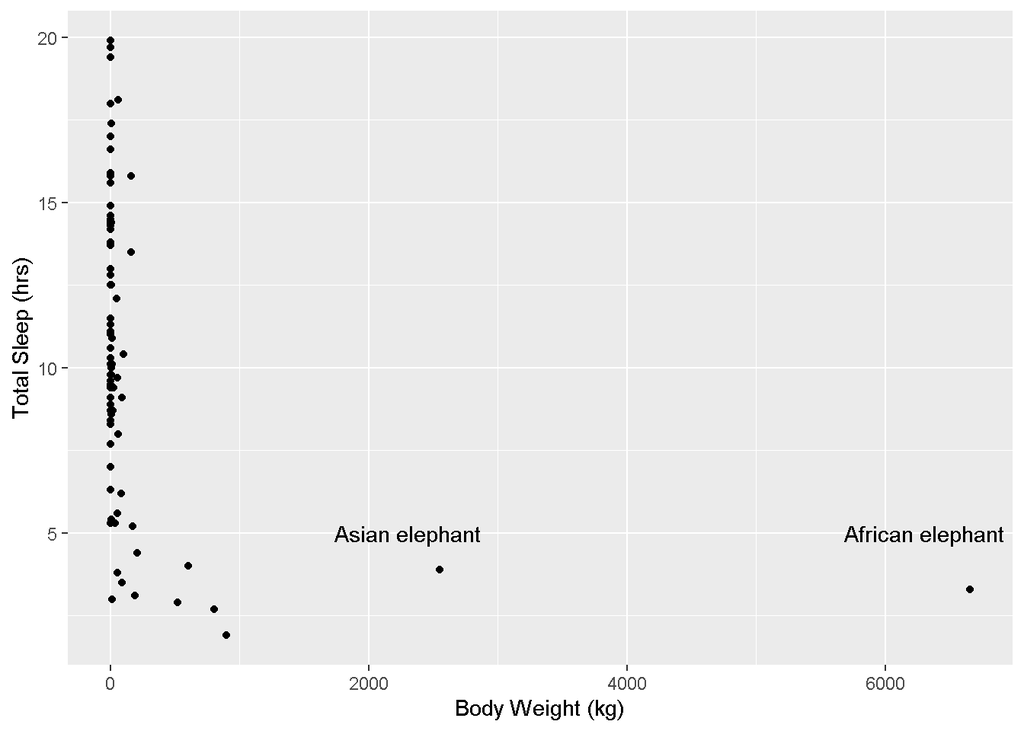

```r
msleep |>
  ggplot(aes(x = bodywt, y = sleep_total)) +
  geom_point() +
  annotate("text", x = 2300, y = 5, label = "Asian elephant") +
  annotate("text", x = 6300, y = 5, label = "African elephant") +
  labs(y = "Total Sleep (hrs)", x = "Body Weight (kg)")
```

```r
large_mammals <- filter(msleep, bodywt < 45) |>
  mutate(brain_prop = brainwt / bodywt)
```

### 6b) Create a scatterplot that evaluates the association between the brain-to-body weight proportion variable you created (put that on the x-axis) and total hours of sleep.

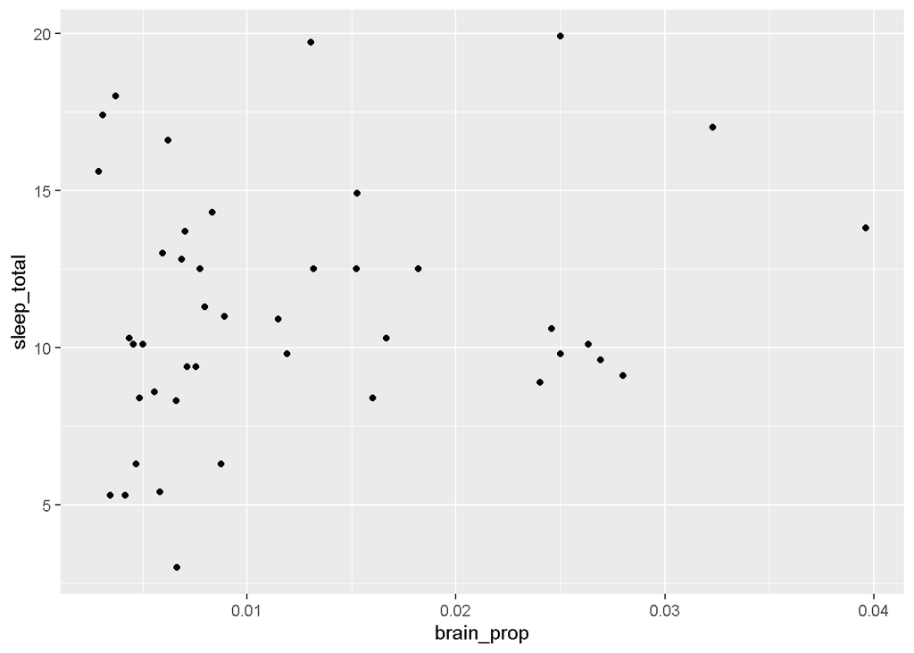

```r
large_mammals |>
  ggplot(aes(x = brain_prop, y = sleep_total)) +
  geom_point()
```

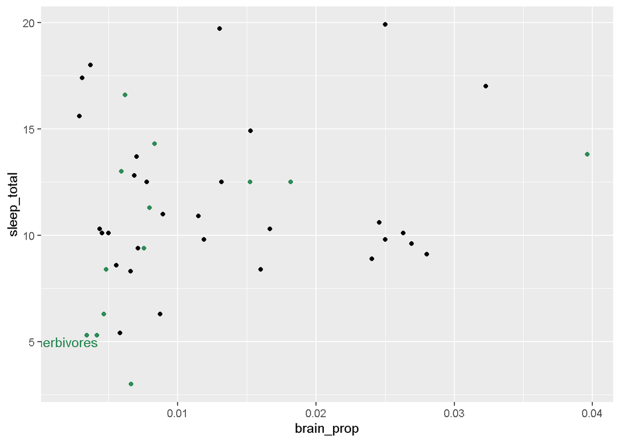

```r
large_mammals |>
  ggplot(aes(x = brain_prop, y = sleep_total)) +
  geom_point() +
  geom_point(data = filter(large_mammals, vore == "herbi"), color = "seagreen") +
  annotate("text", y = 5, x = .002, label = "herbivores", color = "seagreen")
```

### 7) Make one more scatterplot of two variables of interest. Make at least two annotations to the plot of things / trends you find interesting. Some ideas: label your favorite mammal on the plot with its name, add a reference line, highlight endangered animals, etc. Add a label and descriptive title to this plot. Try to make this plot as self-explanatory as possible!

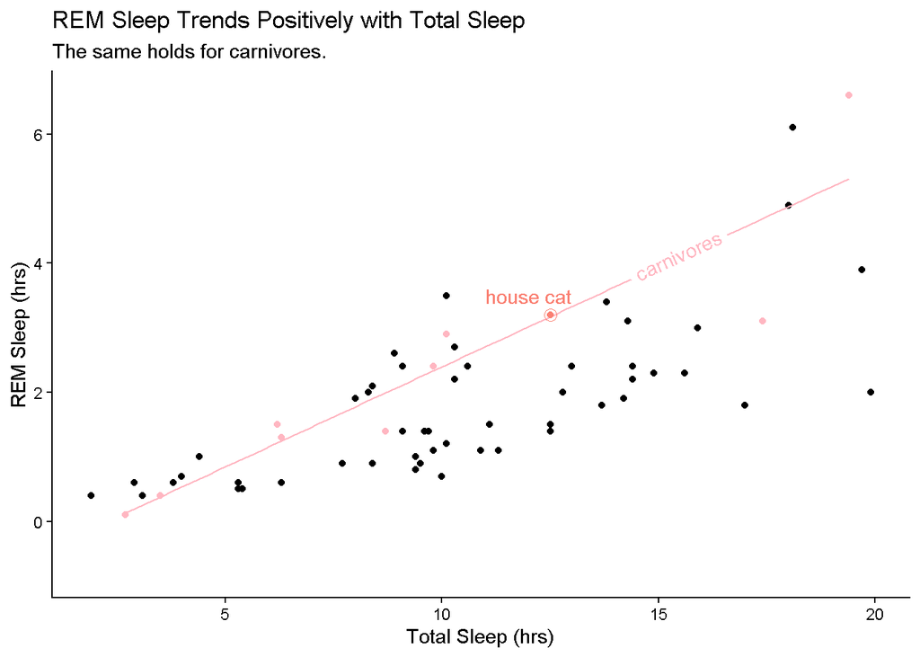

```r
ggplot(msleep, aes(x = sleep_total, y = sleep_rem)) +
  geom_point() +
  geom_point(data = filter(msleep, vore == "carni"), color = "lightpink") +
  geomtextpath::geom_textsmooth(data = filter(msleep, vore == "carni"), color = "lightpink",
                                label = "carnivores", method = "lm", hjust = .8) +
  geom_point(data = filter(msleep, genus == "Felis"), color = "salmon") +
  geom_point(data = filter(msleep, genus == "Felis"), color = "salmon", shape = "circle open", size = 3) +
  annotate("text", x = 12, y = 3.5, label = "house cat", color = "salmon") +
  labs(x = "Total Sleep (hrs)", y = "REM Sleep (hrs)", title = "REM Sleep Trends Positively with Total Sleep",
       subtitle = "The same holds for carnivores.") +
  theme_classic()
```